# PracaDom5_MBogdańska

Magdalena Bogdańska

Modele liniowe i mieszane

Task:

You have data for n patients. For each patient you have his/her blood pressure, gender and type of diabetes (here, let’s assume that there are three types of diabetes: pre, 1 and 2). Let assume that male have blood pressure higher than female (on average) and the difference is delta1 = 1. Then let’s assume that nested effect of diabetes is delta2= (0, 0, 0.5) for male and delta3=(0, 0, 1) for female.

Our goal is to find sample size, for which the test for nested effect (only effect of diabetes) has power 0.8.

## Part 1

Create a simulation study in which for a given n - sample size you will calculate power for hypothesis H0: delta2=0 and delta3=0.

```r
mean_pressure<-120

delta1<-1 #difference between blood pressure in men and women
delta2<-0.5 #nested effect for men with diabetes 2
delta3<-1 #nested effect for woman with diabetes 2

# function which extracts p-values
pvals <- function(n){
    sex<-rep(c("m","w"), length.out=n)
    diabetes <- rep(c("pre", "1", "2"), length.out=n)
    data <- merge(sex, diabetes)
    names(data)<-c("sex","diabetes")

    data$b_pressure<-rnorm(n,mean_pressure,1) + ifelse(data$sex=="m"& data$diabetes=="2",delta1+delta2,delta1)
    +ifelse(data$sex=="w"& data$diabetes=="2",delta3,0)
        summary(aov(b_pressure~sex/diabetes, data))[[1]][1,5]
}

# function calculating power of the test for selected numer of replications (H)
power <- function (n, alpha) {
  p_vals <- replicate(H, pvals(n))
  mean(p_vals < alpha)
}
```

## Part 2

Choose the smallest n for which power is not smaller than 0.8. I.e. what is the minimal number of patients that allows to detect effect of the size (0,0,0.5,0,0,1) with probability larger than 80%.

```r
set.seed(77)

H<-1000
alpha<-0.05 #significance level

n_patients <- seq(5, 50, 1)
power1 <- sapply(n_patients, function (x) power(x, alpha))
n_patients[min(which(power1>0.8))]
```

```
## [1] 42
```

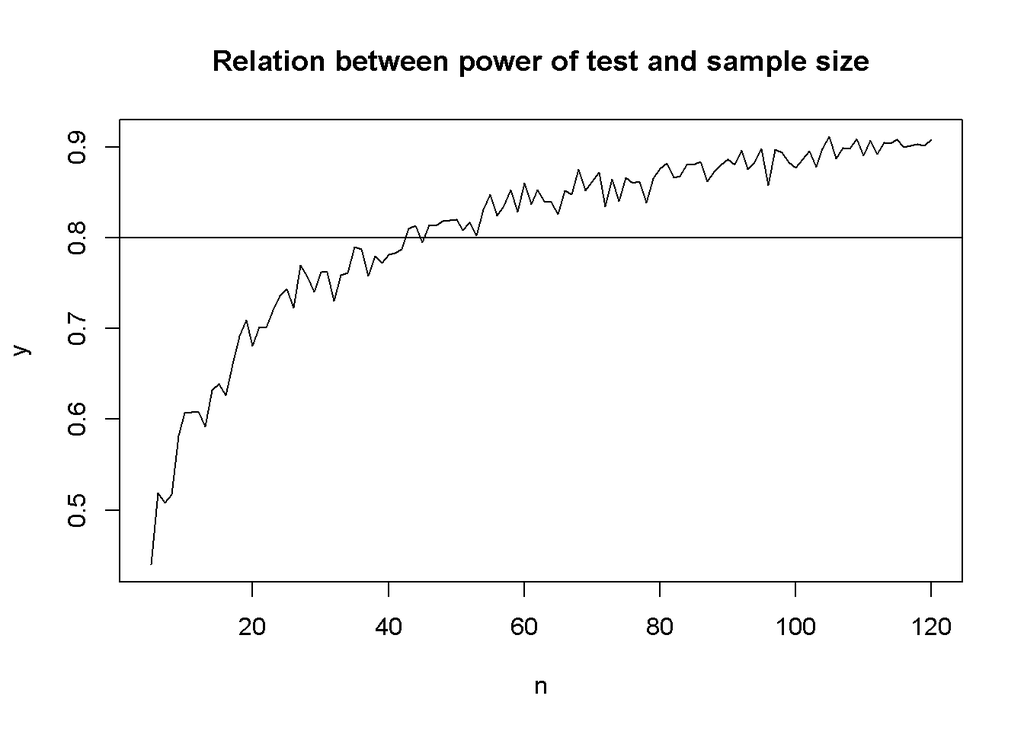

```r
n = seq(5,120, by=1)
y = sapply(n, function (x) power(x, alpha))
plot(n, y, main = "Relation between power of test and sample size", type = "l")
abline(h=0.8)
```